# HW4_Solution

Ykulkarni1@student.gsu.edu

10/8/2021

#### Problem 1 The percentage of cotton in material used to manufacture men’s shirts follows.

1. Compute the sample mean, variance and median.

```r
library(openxlsx)
dat= read.xlsx('/Users/seventails/Downloads/Stat/Week 5/HW4_data.xlsx')
mean(dat$Cotton_Percentage)
```

```
## [1] 34.79844
```

```r
var(dat$Cotton_Percentage)
```

```
## [1] 1.860791
```

```r
median(dat$Cotton_Percentage)
```

```
## [1] 34.7
```

2. Construct a stem-and-leaf display for the data.

```r
stem(dat$Cotton_Percentage)
```

```
##
##   The decimal point is at the |
##
##   32 | 156789
##   33 | 11456666688
##   34 | 011122355666667777779
##   35 | 00111234456789
##   36 | 2346888
##   37 | 13689
```

3. Construct a frequency distribution and histogram for the cotton content.

```r
#Creating a numeric vector of cotton percentages as input to the cut method
percentages= dat$Cotton_Percentage

#Creating bins to sort the percentages into
bins= seq(32, 39, by= 1)

#sort the values into the bins created above
freq= cut(percentages, bins)

#view the factor created above as a table.
transform(table(freq))
```

```
##      freq Freq
## 1 (32,33]    6
## 2 (33,34]   12
## 3 (34,35]   22
## 4 (35,36]   12
## 5 (36,37]    7
## 6 (37,38]    5
## 7 (38,39]    0
```

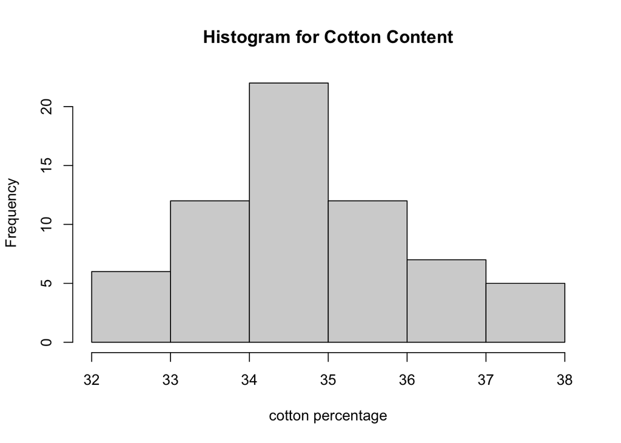

```r
#Create the histogram
hist(percentages, main = "Histogram for Cotton Content", xlab = "cotton percentage")
```

(d) Construct a box plot of the data and comment on the information in this display.

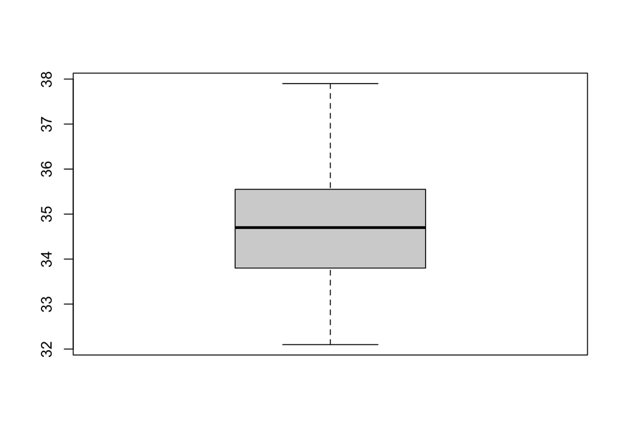

```r
boxplot(dat$Cotton_Percentage)
```

```r
## The min and max ranges betwen 32 and 38.
## The median lies between 34.5 and 35. There are no outliers in the data.
```

#### Problem 2. Suppose X has Bernoulli distribution with parameter p. Show that the sample mean X ̄ is a MVUE of p.

Let $\sf{X_{1}, X_{2},..., X_{n}}$ be Bernoulli trials with success parameter p and set the estimator for $p$ to be $d(X)= \overline{X}$, the sample mean. Then,
$$\begin{aligned}
\ E_{p} \overline{X}&= \frac{1}{n}({EX_{1},EX_{2},...,EX_{n}} )\\
&=\frac{1}{n}(p + p+...+ p)\\
&=p
\end{aligned}$$

#### Problem 3 Use the MLE method to build estimators for the parameters of the following distributions:

1. Bernoulli
   $$\begin{aligned}
   \text {Likelihood function is-}\\
   L(\theta)&= \prod_{i = 1}^{n} p^{X_{i}}(1-p)^{1-X_{i}}\\
   \text{The log-likelihood function is-} \\
   LL(\theta)&= \sum_{i= 1}^{n}log p^{X_{i}}(1-p)^{1-X_{i}}\\
   &=\sum_{i= 1}^{n} X_{i}(\log {p}) + (1-X_{i}) \log{(1-p)}\\
   &= Y\log{p}+ (n-Y)\log{(1-p)} &where\ Y= \sum_{i= 1}^{n} X_{i}
   \end{aligned}$$

Now finding the first derivative of the function and setting it to 0 to find the MLE:

$$\begin{aligned}
\frac{\partial LL(p)}{\partial p}&= Y\frac{1}{p}\ +(n-Y)\frac{-p}{1-p}= 0\\
\hat{p}&= \frac{Y}{n}= \frac{\sum_{i= 1}^{n} X_{i}}{n}\\
\text{The estimator is the mean here}
\end{aligned}$$

2. Exponential
   $$\begin{aligned}
   \text {Likelihood function is-}\\
   L( \lambda, x_{1},x_{2}, ..., x_{n})&= \prod_{i = 1}^{n}\lambda e^{-\lambda x}\\
   &= \lambda ^{n}e^{-\lambda \sum_{i= 1}^{n}X_{i}}\\
   \text{The log-likelihood function is-}\\
   LL(\theta)&= n\log{\lambda}-\lambda \sum_{i= 1}^{n}X_{i} \log{e}\\
   &=n\log{\lambda}-\lambda Y &where\ Y= \sum_{i= 1}^{n} X_{i}\\
   \frac{\partial LL(p)}{\partial p}&= \frac{n}{\lambda} - Y= 0\\
   \hat{\lambda} &= \frac{n}{Y}\\
   \hat{\lambda} &= \frac{n}{\sum_{i=1}^{n}X_{i}}\\
   \text{The estimator is the reciprocal of the mean}\\
   \end{aligned}$$
3. Lognormal
   $$\begin{aligned}
   \text {Likelihood function is-}\\
   L(\theta) &= \prod_{i = 1}^{n}\frac{1}{\sqrt{2\pi\theta_{1}}} e^-{\frac{(X_{i}-\theta_{0})^2}{2\theta_{1}}}\\
   \text{The log-likelihood function is-}\\
   LL(\theta) &= \prod_{i = 1}^{n}\log{\frac{1}{\sqrt{2\pi\theta_{1}}}} e^-{\frac{(X_{i}-\theta_{0})^2}{2\theta_{1}}}\\
   \text{Solving for both }\theta_{0} and \theta_{1}\\
   \hat{\mu}= \hat{\theta_{0}}\\
   \hat{\sigma^2}= \hat{\theta_{1}}
   \end{aligned}$$

#### Problem 6 (24 points total)

1. Calculate the least squares estimates of the slope and intercept. Graph the regression line. (12 points)

```r
n= 20
sigma_Y= 12.7
sigma_Y2= 8.8
sigma_X=1487
sigma_X2=143215
sigma_XY= 1083
S_XX= sigma_X2- (sigma_X^2/n)
S_XY= sigma_XY-((sigma_Y*sigma_X)/n)

b1= S_XY/S_XX
b1
```

```
## [1] 0.004248918
```

```r
b0= sigma_Y/n- (b1*(sigma_X/n))
b0
```

```
## [1] 0.319093
```

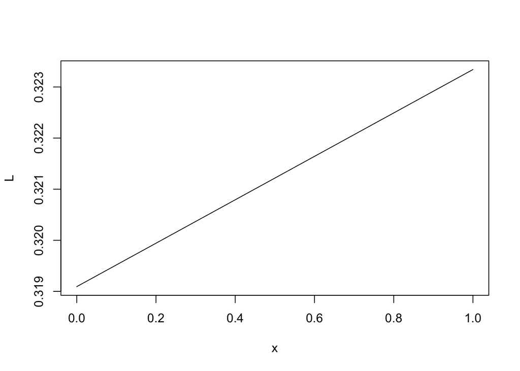

```r
L= function(x= c(-100:100)){
  b0+b1*(x)
}
plot(L)
```

(b) Use the equation of the fitted line to predict what pavement deflection would be ob- served when the surface temperature is 85◦F. (4 points)

```r
b0+(b1*85)
```

```
## [1] 0.680251
```

3. What is the mean pavement deflection when the surface temperature is 90◦F? (4 points)

```r
b0+(b1*90)
```

```
## [1] 0.7014956
```

4. What change in mean pavement deflection would be expected for a 1◦F change in surface temperature? (4 points)

```r
b1
```

```
## [1] 0.004248918
```